# Tugas Praktikum 4 MPDW : AR-MA manual

# White Noise

Pembangkitan data berpola AR, MA, ARMA, dan banyak proses deret waktu lainnya diawali pembangkitan *white noise*. *White noise* merupakan sederet nilai dari peubah bebas stokastik identik. Oleh karena itu, *white noise* memiliki dua karakteristik penting:

1. *White noise* tidak memiliki autokorelasi (**karena saling bebas**)
2. Nilai harapan dan ragam *white noise* sama (**karena berasal dari peubah acak bebas stokastik identik**)

*White noise* dibangkitkan dari suatu peubah acak, umumnya peubah acak normal.

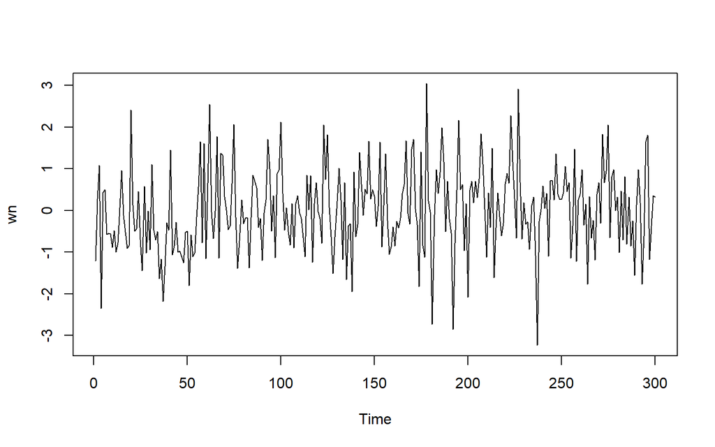

```r
set.seed(1234)
wn <- rnorm(300)
ts.plot(wn)
```

Dapat terlihat bahwa *white noise* tidak memiliki autokorelasi dari ACF. Perhatikan bahwa lag ke-0 adalah korelasi observasi ke-t dengan dirinya sendiri. Nilai korelasi tersebut pasti 1. Sebagai alternatif, lag pertama di plot ACF dapat ditetapkan sebagai 1 (alih-alih 0) dengan menambahkan argumen `xlim(1, lag akhir)`. Plot tersebut dapat disandingkan bersamaan dengan membuat matriks $1 \times 2$ dengan `par(mfrow = c(1,2))`.

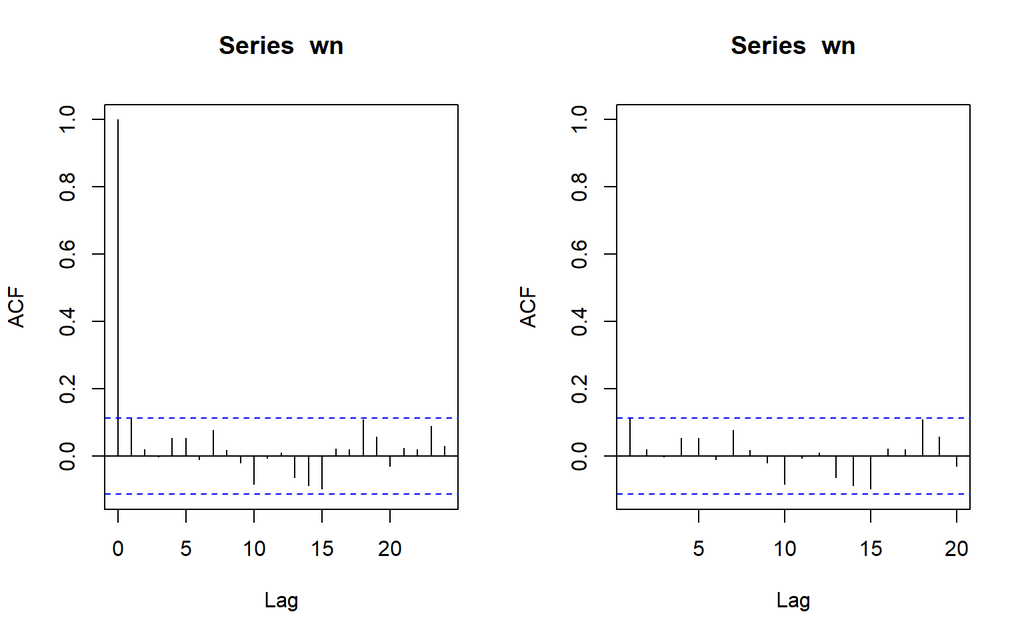

```r
par(mfrow = c(1, 2))
acf(wn)
acf(wn, xlim = c(1, 20))
```

# Proses MA

Proses MA dapat dituliskan sebagai berikut:

$$y_{t} = c + e_t + \theta_{1}e_{t-1} + \theta_{2}e_{t-2} + \dots +
\theta_{q}e_{t-q} = c+{e_t+\sum_{i=1}^p \theta_ie_{t-i}}$$

Terlihat bahwa $e_t$, atau *white noise*, berperan penting dalam pembangkitan proses MA.

## Pembangkitan Proses MA(2)

Akan dicoba membangkitkan MA(2) dengan $\theta = 0.4$ sebanyak 300 observasi dan $c=0$. Karena diperlukan satu nilai awal untuk $e_{t-1}$, masukkan nilai pertama white noise sebagai nilai awal tersebut.

```r
set.seed(1234)
ma <- wn[1:2]
```

Nilai-nilai selanjutnya dapat dicari melalui *loop*. Bentuk loop dapat dilihat dari rumus MA(1) yang hendak dibangkitkan:

$$y_t = e_t+0.4e_{t-1}+0.6e_{t-2}$$

```r
for(i in 3:300){
   ma[i] <- wn[i] + 0.4 * wn[i - 1] + 0.6* wn[i-2]
}
ma
```

```
##   [1] -1.207065749  0.277429242  0.471173424 -1.745463687  0.141510314
##   [6] -0.729712854 -0.114842790 -0.472894305 -1.127948717 -1.443797742
##  [11] -1.171879031 -1.723286222 -1.461924092 -0.845074607  0.519525249
##  [16]  0.312187420  0.020572732 -1.181770516 -1.508255550  1.534249256
##  [21]  0.598119283  1.012450498 -0.556369299 -0.011041246 -0.774213194
##  [26] -1.449939345 -0.420758391 -1.662676381 -0.079747157 -1.556197355
##  [31]  0.718835126 -0.596243221 -0.238298741 -1.070389923 -2.255260716
##  [36] -2.120011486 -3.624543435 -2.913580609 -2.138714925 -1.388210999
##  [41]  1.086560934 -0.768382742 -0.413123964 -1.263954490 -1.619808057
##  [46] -1.534624150 -2.091327966 -2.276021753 -1.689013389 -1.457572736
##  [51] -2.319068111 -1.602598402 -2.425338748 -1.807763414 -1.233628102
##  [56] -0.110845196  1.775654086  0.223607057  2.285258743 -0.979456751
##  [61]  1.157010823  2.116941328  1.378789117  0.845856907 -0.296314421
##  [66]  1.372262398 -0.432336811  1.978634754  1.193531021  1.688995021
##  [71]  0.939220832 -0.250827924 -0.544575725  0.228395751  2.109671129
```

[output cut: 45 more lines]

Selain menggunakan cara di atas, pembangkitan proses MA(2) dapat dilakukan dengan fungsi `arima.sim()` sebagai berikut.

```r
ma2 <- arima.sim(list(order=c(0,0,2), ma=c(0.4, 0.6)), n=300)
ma2
```

```
## Time Series:
## Start = 1
## End = 300
## Frequency = 1
##   [1]  0.471173424 -1.745463687  0.141510314 -0.729712854 -0.114842790
##   [6] -0.472894305 -1.127948717 -1.443797742 -1.171879031 -1.723286222
##  [11] -1.461924092 -0.845074607  0.519525249  0.312187420  0.020572732
##  [16] -1.181770516 -1.508255550  1.534249256  0.598119283  1.012450498
##  [21] -0.556369299 -0.011041246 -0.774213194 -1.449939345 -0.420758391
##  [26] -1.662676381 -0.079747157 -1.556197355  0.718835126 -0.596243221
##  [31] -0.238298741 -1.070389923 -2.255260716 -2.120011486 -3.624543435
##  [36] -2.913580609 -2.138714925 -1.388210999  1.086560934 -0.768382742
##  [41] -0.413123964 -1.263954490 -1.619808057 -1.534624150 -2.091327966
##  [46] -2.276021753 -1.689013389 -1.457572736 -2.319068111 -1.602598402
##  [51] -2.425338748 -1.807763414 -1.233628102 -0.110845196  1.775654086
```

[output cut: 49 more lines]

## Karakteristik MA(2)

### Plot Time Series

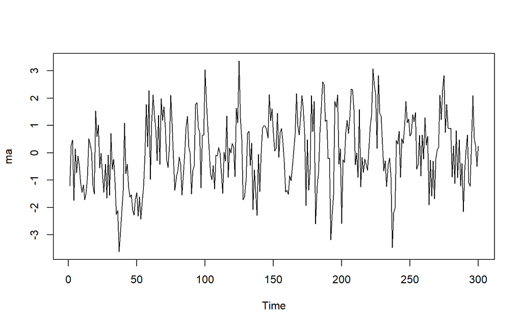

```r
ts.plot(ma)
```

Berdasarkan plot time series, terlihat bahwa data MA(2) yang dibangkitkan stasioner dalam rataan

### Plot ACF

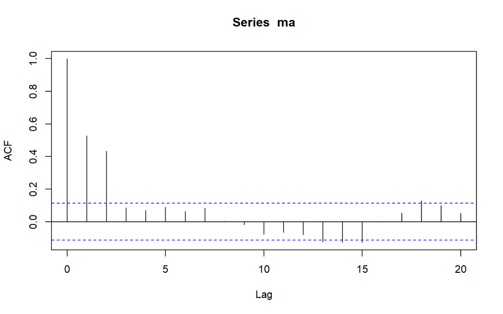

```r
acf(ma,lag.max = 20)
```

Berdasarkan plot ACF tersebut, terlihat bahwa plot ACF *cuts off* di lag kedua

### Plot PACF

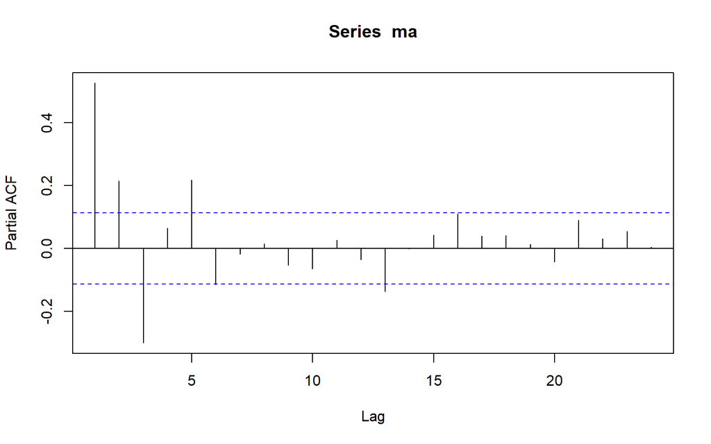

```r
pacf(ma)
```

Berdasarkan plot PACF tersebut, terlihat bahwa plot PACF cenderung *tails off*

### Plot EACF

```r
TSA::eacf(ma)
```

```
## AR/MA
##   0 1 2 3 4 5 6 7 8 9 10 11 12 13
## 0 x x o o o o o o o o o  o  x  x
## 1 x x x o o o o o o o o  o  o  o
## 2 x x x x o o o o o o o  o  o  o
## 3 x x x x x o o o o o o  o  o  o
## 4 x x x x x o o o o o o  o  o  o
## 5 x x x x x o x o o o o  o  o  o
## 6 x x x o x o o x o o o  o  o  o
## 7 x o x o x o o x o o o  o  o  o
```

Berdasarkan pola segitiga nol pada plot EACF, terlihat bahwa segitiga nol berada pada ordo AR(0) dan ordo MA(2)

## Scatterplot Antar Lag

### Korelasi antara $Y_t$ dengan $Y_{t-1}$

```r
#Yt
yt_ma <- ma[-1]
yt_ma
```

```
##   [1]  0.277429242  0.471173424 -1.745463687  0.141510314 -0.729712854
##   [6] -0.114842790 -0.472894305 -1.127948717 -1.443797742 -1.171879031
##  [11] -1.723286222 -1.461924092 -0.845074607  0.519525249  0.312187420
##  [16]  0.020572732 -1.181770516 -1.508255550  1.534249256  0.598119283
##  [21]  1.012450498 -0.556369299 -0.011041246 -0.774213194 -1.449939345
##  [26] -0.420758391 -1.662676381 -0.079747157 -1.556197355  0.718835126
##  [31] -0.596243221 -0.238298741 -1.070389923 -2.255260716 -2.120011486
##  [36] -3.624543435 -2.913580609 -2.138714925 -1.388210999  1.086560934
##  [41] -0.768382742 -0.413123964 -1.263954490 -1.619808057 -1.534624150
##  [46] -2.091327966 -2.276021753 -1.689013389 -1.457572736 -2.319068111
##  [51] -1.602598402 -2.425338748 -1.807763414 -1.233628102 -0.110845196
##  [56]  1.775654086  0.223607057  2.285258743 -0.979456751  1.157010823
##  [61]  2.116941328  1.378789117  0.845856907 -0.296314421  1.372262398
##  [66] -0.432336811  1.978634754  1.193531021  1.688995021  0.939220832
##  [71] -0.250827924 -0.544575725  0.228395751  2.109671129  1.063681873
```

[output cut: 45 more lines]

```r
#Yt-1
yt_1_ma <- ma[-300]
yt_1_ma
```

```
##   [1] -1.207065749  0.277429242  0.471173424 -1.745463687  0.141510314
##   [6] -0.729712854 -0.114842790 -0.472894305 -1.127948717 -1.443797742
##  [11] -1.171879031 -1.723286222 -1.461924092 -0.845074607  0.519525249
##  [16]  0.312187420  0.020572732 -1.181770516 -1.508255550  1.534249256
##  [21]  0.598119283  1.012450498 -0.556369299 -0.011041246 -0.774213194
##  [26] -1.449939345 -0.420758391 -1.662676381 -0.079747157 -1.556197355
##  [31]  0.718835126 -0.596243221 -0.238298741 -1.070389923 -2.255260716
##  [36] -2.120011486 -3.624543435 -2.913580609 -2.138714925 -1.388210999
##  [41]  1.086560934 -0.768382742 -0.413123964 -1.263954490 -1.619808057
##  [46] -1.534624150 -2.091327966 -2.276021753 -1.689013389 -1.457572736
##  [51] -2.319068111 -1.602598402 -2.425338748 -1.807763414 -1.233628102
##  [56] -0.110845196  1.775654086  0.223607057  2.285258743 -0.979456751
##  [61]  1.157010823  2.116941328  1.378789117  0.845856907 -0.296314421
##  [66]  1.372262398 -0.432336811  1.978634754  1.193531021  1.688995021
##  [71]  0.939220832 -0.250827924 -0.544575725  0.228395751  2.109671129
```

[output cut: 45 more lines]

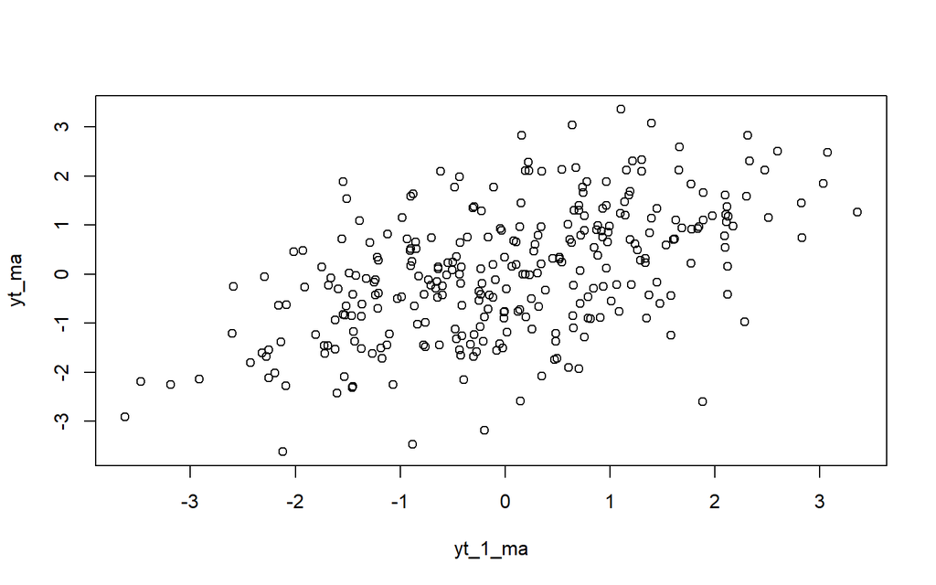

```r
plot(y=yt_ma,x=yt_1_ma)
```

Berdasarkan scatterplot tersebut, terlihat bahwa terdapat hubungan positif antara $Y_t$ dengan $Y_{t-1}$. Hal ini sesuai dengan teori yang ada

```r
cor(yt_ma,yt_1_ma)
```

```
## [1] 0.5274606
```

Korelasi antara $Y_t$ dengan $Y_{t-1}$ dari hasil simulasi mendekati perhitungan teoritis yaitu

$$\rho_1 =
\frac{\theta_1+\theta_1\theta_2}
{1+\theta_1^2+\theta_2^2} =
\frac{0.4+(0.4)(0.6)}
{1+(0.4)^2+(0.6)^2}
=
\frac{0.64}{1.52}
\approx 0.421$$

### Korelasi antara $Y_t$ dengan $Y_{t-2}$

```r
#Yt
yt_ma2 <- ma[-c(1,2)]
yt_ma2
```

```
##   [1]  0.471173424 -1.745463687  0.141510314 -0.729712854 -0.114842790
##   [6] -0.472894305 -1.127948717 -1.443797742 -1.171879031 -1.723286222
##  [11] -1.461924092 -0.845074607  0.519525249  0.312187420  0.020572732
##  [16] -1.181770516 -1.508255550  1.534249256  0.598119283  1.012450498
##  [21] -0.556369299 -0.011041246 -0.774213194 -1.449939345 -0.420758391
##  [26] -1.662676381 -0.079747157 -1.556197355  0.718835126 -0.596243221
##  [31] -0.238298741 -1.070389923 -2.255260716 -2.120011486 -3.624543435
##  [36] -2.913580609 -2.138714925 -1.388210999  1.086560934 -0.768382742
##  [41] -0.413123964 -1.263954490 -1.619808057 -1.534624150 -2.091327966
##  [46] -2.276021753 -1.689013389 -1.457572736 -2.319068111 -1.602598402
##  [51] -2.425338748 -1.807763414 -1.233628102 -0.110845196  1.775654086
##  [56]  0.223607057  2.285258743 -0.979456751  1.157010823  2.116941328
##  [61]  1.378789117  0.845856907 -0.296314421  1.372262398 -0.432336811
##  [66]  1.978634754  1.193531021  1.688995021  0.939220832 -0.250827924
##  [71] -0.544575725  0.228395751  2.109671129  1.063681873 -0.209897795
```

[output cut: 45 more lines]

```r
#Yt-2
yt_2_ma <- ma[-c(299,300)]
yt_2_ma
```

```
##   [1] -1.207065749  0.277429242  0.471173424 -1.745463687  0.141510314
##   [6] -0.729712854 -0.114842790 -0.472894305 -1.127948717 -1.443797742
##  [11] -1.171879031 -1.723286222 -1.461924092 -0.845074607  0.519525249
##  [16]  0.312187420  0.020572732 -1.181770516 -1.508255550  1.534249256
##  [21]  0.598119283  1.012450498 -0.556369299 -0.011041246 -0.774213194
##  [26] -1.449939345 -0.420758391 -1.662676381 -0.079747157 -1.556197355
##  [31]  0.718835126 -0.596243221 -0.238298741 -1.070389923 -2.255260716
##  [36] -2.120011486 -3.624543435 -2.913580609 -2.138714925 -1.388210999
##  [41]  1.086560934 -0.768382742 -0.413123964 -1.263954490 -1.619808057
##  [46] -1.534624150 -2.091327966 -2.276021753 -1.689013389 -1.457572736
##  [51] -2.319068111 -1.602598402 -2.425338748 -1.807763414 -1.233628102
##  [56] -0.110845196  1.775654086  0.223607057  2.285258743 -0.979456751
##  [61]  1.157010823  2.116941328  1.378789117  0.845856907 -0.296314421
##  [66]  1.372262398 -0.432336811  1.978634754  1.193531021  1.688995021
##  [71]  0.939220832 -0.250827924 -0.544575725  0.228395751  2.109671129
```

[output cut: 45 more lines]

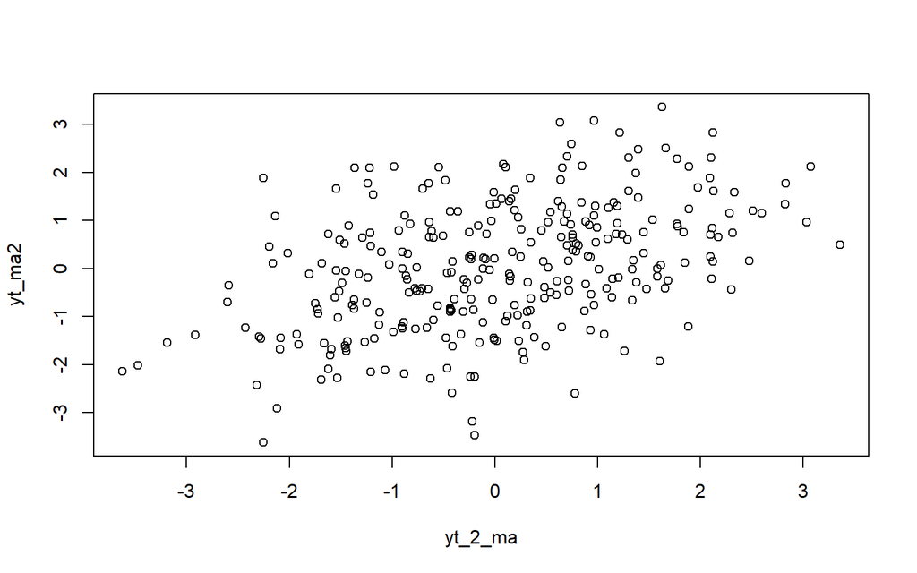

```r
plot(y=yt_ma2,x=yt_2_ma)
```

Berdasarkan scatterplot tersebut, terlihat bahwa cenderung terdapat hubungan positif antara $Y_t$ dengan $Y_{t-2}$.

```r
cor(yt_ma2,yt_2_ma)
```

```
## [1] 0.4339293
```

Korelasi antara $Y_t$ dengan $Y_{t-2}$ hasil simulasi mendekati teori yang ada yaitu

$$\rho_2 =
\frac{\theta_2}
{1+\theta_1^2+\theta_2^2} =
\frac{0.6}
{1+(0.4)^2+(0.6)^2}
=
\frac{0.6}{1.52}
\approx 0.395$$

### Korelasi antara $Y_t$ dengan $Y_{t-3}$

```r
#Yt
yt_ma3 <- ma[-c(1,2,3)]
yt_ma3
```

```
##   [1] -1.745463687  0.141510314 -0.729712854 -0.114842790 -0.472894305
##   [6] -1.127948717 -1.443797742 -1.171879031 -1.723286222 -1.461924092
##  [11] -0.845074607  0.519525249  0.312187420  0.020572732 -1.181770516
##  [16] -1.508255550  1.534249256  0.598119283  1.012450498 -0.556369299
##  [21] -0.011041246 -0.774213194 -1.449939345 -0.420758391 -1.662676381
##  [26] -0.079747157 -1.556197355  0.718835126 -0.596243221 -0.238298741
##  [31] -1.070389923 -2.255260716 -2.120011486 -3.624543435 -2.913580609
##  [36] -2.138714925 -1.388210999  1.086560934 -0.768382742 -0.413123964
##  [41] -1.263954490 -1.619808057 -1.534624150 -2.091327966 -2.276021753
##  [46] -1.689013389 -1.457572736 -2.319068111 -1.602598402 -2.425338748
##  [51] -1.807763414 -1.233628102 -0.110845196  1.775654086  0.223607057
##  [56]  2.285258743 -0.979456751  1.157010823  2.116941328  1.378789117
##  [61]  0.845856907 -0.296314421  1.372262398 -0.432336811  1.978634754
##  [66]  1.193531021  1.688995021  0.939220832 -0.250827924 -0.544575725
##  [71]  0.228395751  2.109671129  1.063681873 -0.209897795 -1.371901203
```

[output cut: 45 more lines]

```r
#Yt-3
yt_3_ma <- ma[-c(298,299,300)]
yt_3_ma
```

```
##   [1] -1.207065749  0.277429242  0.471173424 -1.745463687  0.141510314
##   [6] -0.729712854 -0.114842790 -0.472894305 -1.127948717 -1.443797742
##  [11] -1.171879031 -1.723286222 -1.461924092 -0.845074607  0.519525249
##  [16]  0.312187420  0.020572732 -1.181770516 -1.508255550  1.534249256
##  [21]  0.598119283  1.012450498 -0.556369299 -0.011041246 -0.774213194
##  [26] -1.449939345 -0.420758391 -1.662676381 -0.079747157 -1.556197355
##  [31]  0.718835126 -0.596243221 -0.238298741 -1.070389923 -2.255260716
##  [36] -2.120011486 -3.624543435 -2.913580609 -2.138714925 -1.388210999
##  [41]  1.086560934 -0.768382742 -0.413123964 -1.263954490 -1.619808057
##  [46] -1.534624150 -2.091327966 -2.276021753 -1.689013389 -1.457572736
##  [51] -2.319068111 -1.602598402 -2.425338748 -1.807763414 -1.233628102
##  [56] -0.110845196  1.775654086  0.223607057  2.285258743 -0.979456751
##  [61]  1.157010823  2.116941328  1.378789117  0.845856907 -0.296314421
##  [66]  1.372262398 -0.432336811  1.978634754  1.193531021  1.688995021
##  [71]  0.939220832 -0.250827924 -0.544575725  0.228395751  2.109671129
```

[output cut: 45 more lines]

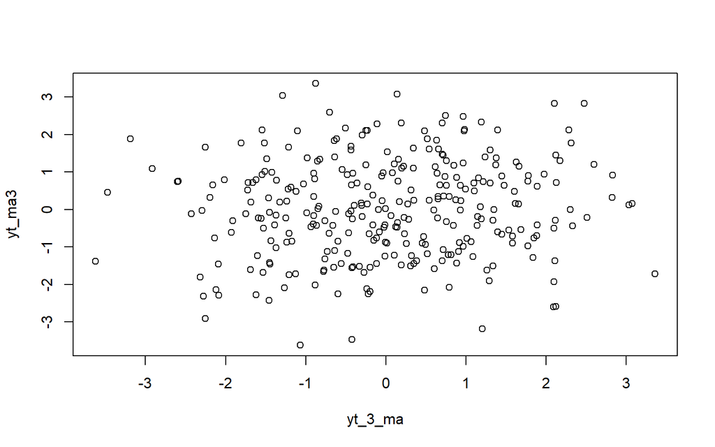

```r
plot(y=yt_ma3,x=yt_3_ma)
```

Berdasarkan scatterplot tersebut, terlihat bahwa cenderung tidak terdapat hubungan antara $Y_t$ dengan $Y_{t-3}$.

```r
cor(yt_ma3,yt_3_ma)
```

```
## [1] 0.08555282
```

Korelasi antara $Y_t$ dengan $Y_{t-3}$ hasil simulasi mendekati teori yang ada yaitu 0.

Secara umum:

$$\rho_k=0,\quad k>q$$
Karena $q=2$ dan $k=3$, maka:

$$\rho_3=0$$

# Proses AR

Proses AR dapat dituliskan sebagai berikut:

$$y_{t} = c + e_t + \phi_{1}Y_{t-1} +
\phi_{2}Y_{t-2} + \dots + \phi_{q}Y_{t-q} = c+{e_t+\sum_{i=1}^p
\phi_iY_{t-i}}$$
Terlihat bahwa $Y_t$ berperan penting dalam pembangkitan proses AR.

## Pembangkitan Proses AR(2)

Akan dicoba membangkitkan proses AR paling sederhana, yaitu AR(2) dengan $\phi1 = 0.5$ dan $\phi2 = 0.2$ sebanyak 300 observasi dan $c=0$.

```r
set.seed(1234)
```

Nilai-nilai selanjutnya dapat dicari melalui *loop*. Bentuk loop dapat dilihat dari rumus AR(2) yang hendak dibangkitkan:

$$Y_t = e_t+0.5Y_{t-1}+0.2Y_{t-2}$$

```r
n<-length(wn)
n
```

```
## [1] 300
```

```r
ar <- c(1:n)

ar[1] <- wn[1]
ar[2] <- wn[2]

for (i in 3:n) {ar[i]<-wn[i]+0.5*ar[i-1]+0.2*ar[i-2]}
ar
```

```
##   [1] -1.207065749  0.277429242  0.981742648 -1.799340530 -0.274197047
##   [6]  0.009089263 -0.625034738 -0.857331372 -1.118124633 -1.620566420
##  [11] -1.511100836 -2.078050147 -2.117499135 -1.409900780 -0.168956158
##  [16] -0.476743729 -0.783172602 -1.398130464 -1.692871432  1.289773370
##  [21]  0.440400618 -0.012530914 -0.358733205  0.277716656 -0.626608560
##  [26] -1.705965859 -0.403548921 -1.566623355 -0.879159762 -1.688853153
##  [31]  0.082039017 -0.772344201 -1.079204335 -1.195329068 -2.442598870
##  [36] -2.627984511 -3.982551678 -3.857865933 -3.019737161 -2.747339308
##  [41] -0.528120821 -1.882170996 -1.902074296 -1.608094349 -2.178802110
##  [46] -2.379534243 -2.732845736 -3.094315602 -2.617555067 -2.424490611
##  [51] -3.541787576 -2.837867835 -3.236181057 -3.200626105 -2.409858787
##  [56] -1.281998796  0.524846317 -0.767330024  1.327213880 -0.647667612
##  [61]  0.598197434  2.718556265  1.444157230  0.596156288  0.579304834
##  [66]  2.185968123  0.070237292  1.840139450  2.263681974  1.836341674
##  [71]  1.377800070  0.600699632  0.209385897  0.873119442  2.548707762
```

[output cut: 45 more lines]

Selain menggunakan cara di atas, pembangkitan proses AR dapat dilakukan dengan fungsi `arima.sim()` sebagai berikut.

```r
ar2 <- arima.sim(list(order=c(2,0,0), ar=c(0.5, 0.2)), n=300)
ar2
```

```
## Time Series:
## Start = 1
## End = 300
## Frequency = 1
##   [1] -1.7066325607 -0.4040571790 -1.5670108246 -0.8794551485 -1.6890783403
##   [6]  0.0818673463 -0.7724750738 -1.0793041051 -1.1954051279 -2.4426568541
##  [11] -2.6280287147 -3.9825853771 -3.8578916236 -3.0197567460 -2.7473542381
##  [16] -0.5281322030 -1.8821796728 -1.9020809107 -1.6080993919 -2.1788059544
##  [21] -2.3795371734 -2.7328479702 -3.0943173054 -2.6175563658 -2.4244916012
##  [26] -3.5417883306 -2.8378684102 -3.2361814957 -3.2006264394 -2.4098590424
##  [31] -1.2819989901  0.5248461693 -0.7673301373  1.3272137941 -0.6476676781
##  [36]  0.5981973841  2.7185562271  1.4441572006  0.5961562661  0.5793048174
##  [41]  2.1859681101  0.0702372818  1.8401394423  2.2636819683  1.8363416698
##  [46]  1.3778000670  0.6006996293  0.2093858952  0.8731194410  2.5487077608
##  [51]  1.2955793561 -0.2331697165 -0.5810507641 -0.0788975632 -0.4727180494
```

[output cut: 49 more lines]

## Karakteristik AR(2)

### Plot Time Series

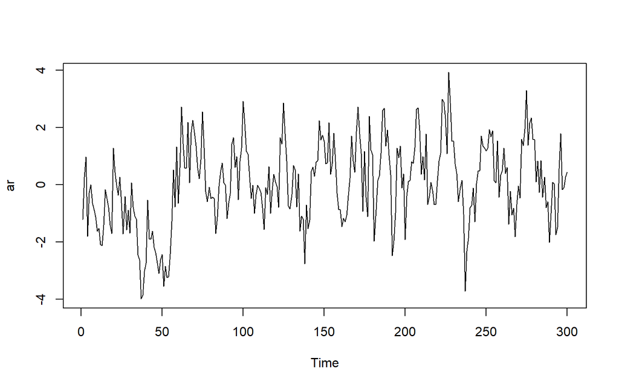

```r
ts.plot(ar)
```

Berdasarkan plot time series tersebut terlihat bahwa data cenderung stasioner pada rataan

### Plot ACF

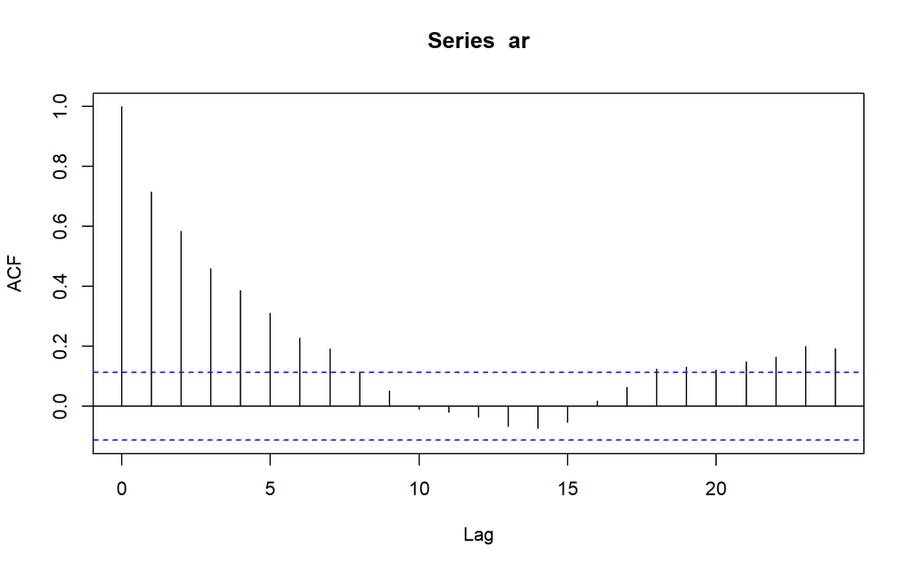

```r
acf(ar)
```

Berdasarkan plot ACF tersebut terlihat bahwa plot ACF cenderung *tails off* dan cenderung membentuk pola grafik sinus

### Plot PACF

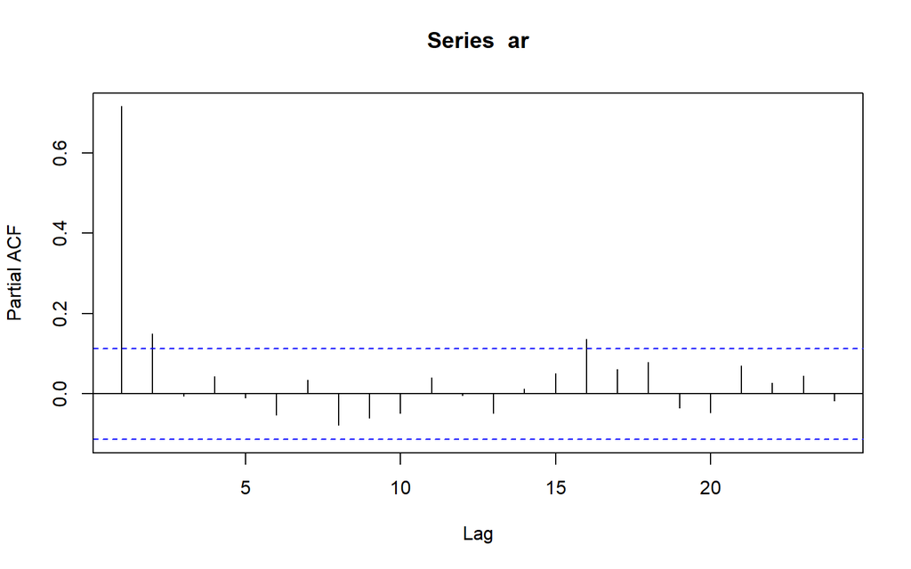

```r
pacf(ar)
```

Berdasarkan plot PACF tersebut, terlihat bahwa plot PACF *cuts off* pada lag kedua, sejalan dengan teori yang ada

### Plot EACF

```r
TSA::eacf(ar)
```

```
## AR/MA
##   0 1 2 3 4 5 6 7 8 9 10 11 12 13
## 0 x x x x x x x o o o o  o  o  o
## 1 x o o o o o o o o o o  o  o  o
## 2 o o o o o o o o o o o  o  o  o
## 3 x x o o o o o o o o o  o  o  o
## 4 x x o o o o o o o o o  o  o  o
## 5 x x o x o o x o o o o  o  o  o
## 6 x x x x o o o o o o o  o  o  o
## 7 x x x o x x o o o o o  o  o  o
```

Berdasarkan pola segitiga nol pada plot EACF, terlihat bahwa segitiga nol berada pada ordo AR(2) dan ordo MA(0)

## Scatterplot Antar Lag

### Korelasi antara $Y_t$ dengan $Y_{t-1}$

```r
#Yt
yt_ar <- ar[-1]
yt_ar
```

```
##   [1]  0.277429242  0.981742648 -1.799340530 -0.274197047  0.009089263
##   [6] -0.625034738 -0.857331372 -1.118124633 -1.620566420 -1.511100836
##  [11] -2.078050147 -2.117499135 -1.409900780 -0.168956158 -0.476743729
##  [16] -0.783172602 -1.398130464 -1.692871432  1.289773370  0.440400618
##  [21] -0.012530914 -0.358733205  0.277716656 -0.626608560 -1.705965859
##  [26] -0.403548921 -1.566623355 -0.879159762 -1.688853153  0.082039017
##  [31] -0.772344201 -1.079204335 -1.195329068 -2.442598870 -2.627984511
##  [36] -3.982551678 -3.857865933 -3.019737161 -2.747339308 -0.528120821
##  [41] -1.882170996 -1.902074296 -1.608094349 -2.178802110 -2.379534243
##  [46] -2.732845736 -3.094315602 -2.617555067 -2.424490611 -3.541787576
##  [51] -2.837867835 -3.236181057 -3.200626105 -2.409858787 -1.281998796
##  [56]  0.524846317 -0.767330024  1.327213880 -0.647667612  0.598197434
##  [61]  2.718556265  1.444157230  0.596156288  0.579304834  2.185968123
##  [66]  0.070237292  1.840139450  2.263681974  1.836341674  1.377800070
##  [71]  0.600699632  0.209385897  0.873119442  2.548707762  1.295579357
```

[output cut: 45 more lines]

```r
#Yt-1
yt_1_ar <- ar[-300]
yt_1_ar
```

```
##   [1] -1.207065749  0.277429242  0.981742648 -1.799340530 -0.274197047
##   [6]  0.009089263 -0.625034738 -0.857331372 -1.118124633 -1.620566420
##  [11] -1.511100836 -2.078050147 -2.117499135 -1.409900780 -0.168956158
##  [16] -0.476743729 -0.783172602 -1.398130464 -1.692871432  1.289773370
##  [21]  0.440400618 -0.012530914 -0.358733205  0.277716656 -0.626608560
##  [26] -1.705965859 -0.403548921 -1.566623355 -0.879159762 -1.688853153
##  [31]  0.082039017 -0.772344201 -1.079204335 -1.195329068 -2.442598870
##  [36] -2.627984511 -3.982551678 -3.857865933 -3.019737161 -2.747339308
##  [41] -0.528120821 -1.882170996 -1.902074296 -1.608094349 -2.178802110
##  [46] -2.379534243 -2.732845736 -3.094315602 -2.617555067 -2.424490611
##  [51] -3.541787576 -2.837867835 -3.236181057 -3.200626105 -2.409858787
##  [56] -1.281998796  0.524846317 -0.767330024  1.327213880 -0.647667612
##  [61]  0.598197434  2.718556265  1.444157230  0.596156288  0.579304834
##  [66]  2.185968123  0.070237292  1.840139450  2.263681974  1.836341674
##  [71]  1.377800070  0.600699632  0.209385897  0.873119442  2.548707762
```

[output cut: 45 more lines]

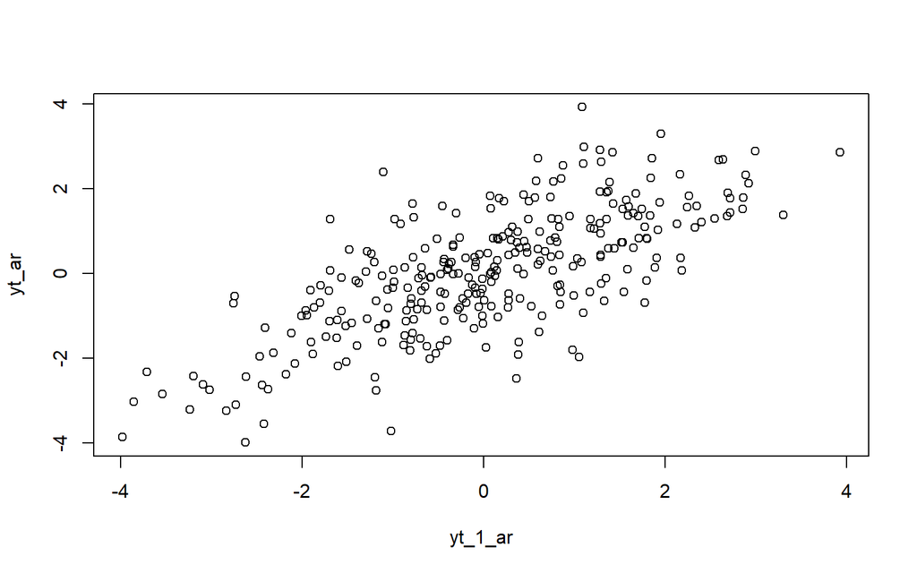

```r
plot(y=yt_ar,x=yt_1_ar)
```

Berdasarkan scatterplot tersebut, terlihat bahwa terdapat hubungan positif antara $Y_t$ dengan $Y_{t-1}$. Hal ini sesuai dengan teori yang ada

```r
cor(yt_ar,yt_1_ar)
```

```
## [1] 0.7165728
```

Korelasi antara $Y_t$ dengan $Y_{t-1}$ dari hasil simulasi mendekati nilai teoritis yaitu:

$$\rho_1 = \frac{\phi_1}{1-\phi_2} = \frac{0.5}{1-0.2}=0.625$$

### Korelasi antara $Y_t$ dengan $Y_{t-2}$

```r
#Yt
yt_ar2 <- ar[-c(1,2)]
yt_ar2
```

```
##   [1]  0.981742648 -1.799340530 -0.274197047  0.009089263 -0.625034738
##   [6] -0.857331372 -1.118124633 -1.620566420 -1.511100836 -2.078050147
##  [11] -2.117499135 -1.409900780 -0.168956158 -0.476743729 -0.783172602
##  [16] -1.398130464 -1.692871432  1.289773370  0.440400618 -0.012530914
##  [21] -0.358733205  0.277716656 -0.626608560 -1.705965859 -0.403548921
##  [26] -1.566623355 -0.879159762 -1.688853153  0.082039017 -0.772344201
##  [31] -1.079204335 -1.195329068 -2.442598870 -2.627984511 -3.982551678
##  [36] -3.857865933 -3.019737161 -2.747339308 -0.528120821 -1.882170996
##  [41] -1.902074296 -1.608094349 -2.178802110 -2.379534243 -2.732845736
##  [46] -3.094315602 -2.617555067 -2.424490611 -3.541787576 -2.837867835
##  [51] -3.236181057 -3.200626105 -2.409858787 -1.281998796  0.524846317
##  [56] -0.767330024  1.327213880 -0.647667612  0.598197434  2.718556265
##  [61]  1.444157230  0.596156288  0.579304834  2.185968123  0.070237292
##  [66]  1.840139450  2.263681974  1.836341674  1.377800070  0.600699632
##  [71]  0.209385897  0.873119442  2.548707762  1.295579357 -0.233169716
```

[output cut: 45 more lines]

```r
#Yt-2
yt_2_ar <- ar[-c(299,300)]
yt_2_ar
```

```
##   [1] -1.207065749  0.277429242  0.981742648 -1.799340530 -0.274197047
##   [6]  0.009089263 -0.625034738 -0.857331372 -1.118124633 -1.620566420
##  [11] -1.511100836 -2.078050147 -2.117499135 -1.409900780 -0.168956158
##  [16] -0.476743729 -0.783172602 -1.398130464 -1.692871432  1.289773370
##  [21]  0.440400618 -0.012530914 -0.358733205  0.277716656 -0.626608560
##  [26] -1.705965859 -0.403548921 -1.566623355 -0.879159762 -1.688853153
##  [31]  0.082039017 -0.772344201 -1.079204335 -1.195329068 -2.442598870
##  [36] -2.627984511 -3.982551678 -3.857865933 -3.019737161 -2.747339308
##  [41] -0.528120821 -1.882170996 -1.902074296 -1.608094349 -2.178802110
##  [46] -2.379534243 -2.732845736 -3.094315602 -2.617555067 -2.424490611
##  [51] -3.541787576 -2.837867835 -3.236181057 -3.200626105 -2.409858787
##  [56] -1.281998796  0.524846317 -0.767330024  1.327213880 -0.647667612
##  [61]  0.598197434  2.718556265  1.444157230  0.596156288  0.579304834
##  [66]  2.185968123  0.070237292  1.840139450  2.263681974  1.836341674
##  [71]  1.377800070  0.600699632  0.209385897  0.873119442  2.548707762
```

[output cut: 45 more lines]

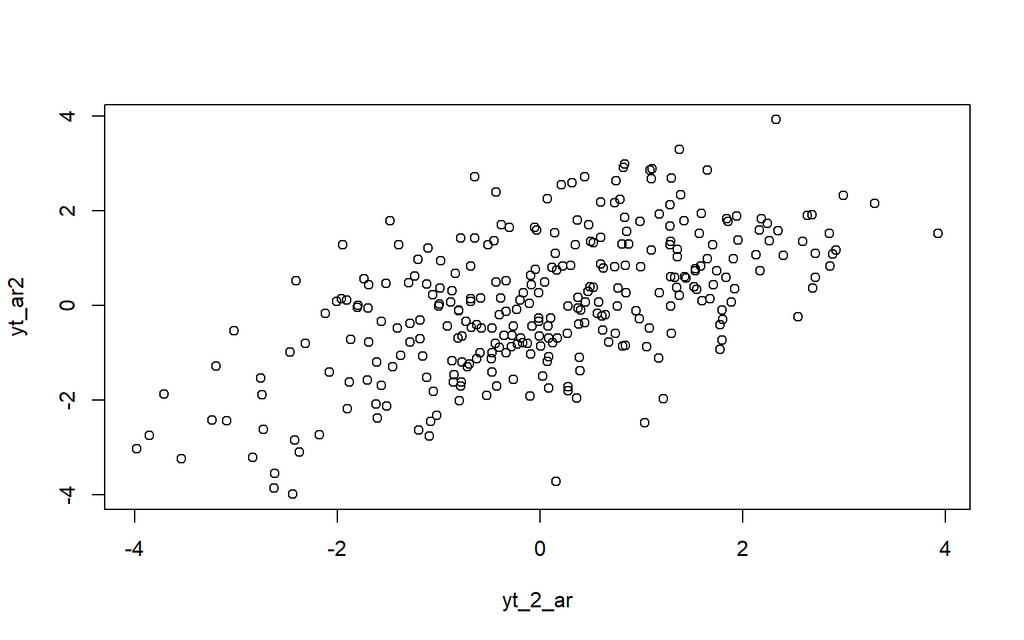

```r
plot(y=yt_ar2,x=yt_2_ar)
```

Berdasarkan scatterplot tersebut, terlihat bahwa terdapat hubungan positif antara $Y_t$ dengan $Y_{t-2}$. Hal ini sesuai dengan teori yang ada

```r
cor(yt_ar2,yt_2_ar)
```

```
## [1] 0.5856318
```

Korelasi antara $Y_t$ dengan $Y_{t-2}$ dari hasil simulasi mendekati nilai teoritis yaitu:

$$\rho_2 = \phi_1\rho_1+\phi_2 =(0.5)(0.625)+0.2=0.5125$$

### Korelasi antara $Y_t$ dengan $Y_{t-3}$

```r
#Yt
yt_ar3 <- ar[-c(1,2,3)]
yt_ar3
```

```
##   [1] -1.799340530 -0.274197047  0.009089263 -0.625034738 -0.857331372
##   [6] -1.118124633 -1.620566420 -1.511100836 -2.078050147 -2.117499135
##  [11] -1.409900780 -0.168956158 -0.476743729 -0.783172602 -1.398130464
##  [16] -1.692871432  1.289773370  0.440400618 -0.012530914 -0.358733205
##  [21]  0.277716656 -0.626608560 -1.705965859 -0.403548921 -1.566623355
##  [26] -0.879159762 -1.688853153  0.082039017 -0.772344201 -1.079204335
##  [31] -1.195329068 -2.442598870 -2.627984511 -3.982551678 -3.857865933
##  [36] -3.019737161 -2.747339308 -0.528120821 -1.882170996 -1.902074296
##  [41] -1.608094349 -2.178802110 -2.379534243 -2.732845736 -3.094315602
##  [46] -2.617555067 -2.424490611 -3.541787576 -2.837867835 -3.236181057
##  [51] -3.200626105 -2.409858787 -1.281998796  0.524846317 -0.767330024
##  [56]  1.327213880 -0.647667612  0.598197434  2.718556265  1.444157230
##  [61]  0.596156288  0.579304834  2.185968123  0.070237292  1.840139450
##  [66]  2.263681974  1.836341674  1.377800070  0.600699632  0.209385897
##  [71]  0.873119442  2.548707762  1.295579357 -0.233169716 -0.581050764
```

[output cut: 45 more lines]

```r
#Yt-3
yt_3_ar <- ar[-c(298, 299,300)]
yt_3_ar
```

```
##   [1] -1.207065749  0.277429242  0.981742648 -1.799340530 -0.274197047
##   [6]  0.009089263 -0.625034738 -0.857331372 -1.118124633 -1.620566420
##  [11] -1.511100836 -2.078050147 -2.117499135 -1.409900780 -0.168956158
##  [16] -0.476743729 -0.783172602 -1.398130464 -1.692871432  1.289773370
##  [21]  0.440400618 -0.012530914 -0.358733205  0.277716656 -0.626608560
##  [26] -1.705965859 -0.403548921 -1.566623355 -0.879159762 -1.688853153
##  [31]  0.082039017 -0.772344201 -1.079204335 -1.195329068 -2.442598870
##  [36] -2.627984511 -3.982551678 -3.857865933 -3.019737161 -2.747339308
##  [41] -0.528120821 -1.882170996 -1.902074296 -1.608094349 -2.178802110
##  [46] -2.379534243 -2.732845736 -3.094315602 -2.617555067 -2.424490611
##  [51] -3.541787576 -2.837867835 -3.236181057 -3.200626105 -2.409858787
##  [56] -1.281998796  0.524846317 -0.767330024  1.327213880 -0.647667612
##  [61]  0.598197434  2.718556265  1.444157230  0.596156288  0.579304834
##  [66]  2.185968123  0.070237292  1.840139450  2.263681974  1.836341674
##  [71]  1.377800070  0.600699632  0.209385897  0.873119442  2.548707762
```

[output cut: 45 more lines]

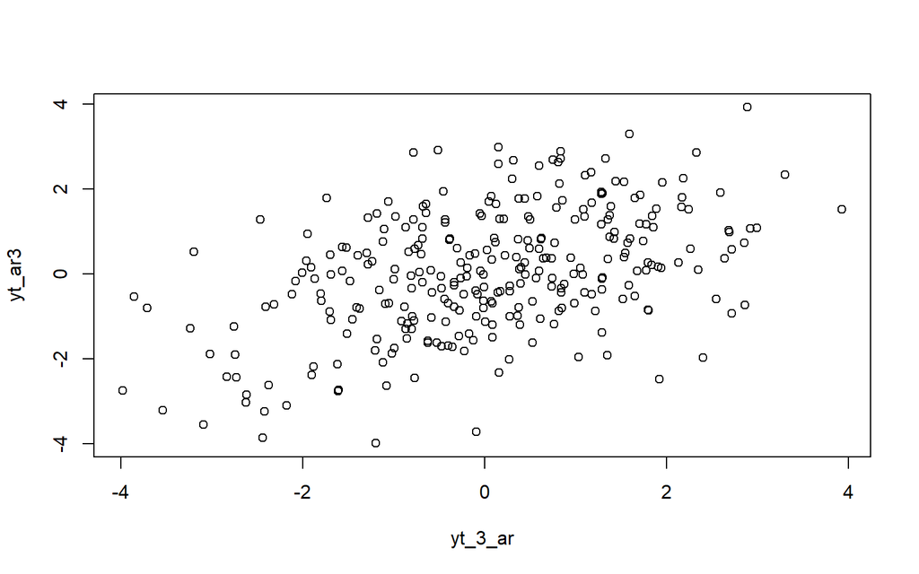

```r
plot(y=yt_ar3,x=yt_3_ar)
```

Berdasarkan scatterplot tersebut, terlihat bahwa terdapat hubungan postiif antara $Y_t$ dengan $Y_{t-3}$. Hal ini sesuai dengan teori yang ada

```r
cor(yt_ar3,yt_3_ar)
```

```
## [1] 0.4609517
```

Korelasi antara $Y_t$ dengan $Y_{t-3}$ dari hasil simulasi mendekati nilai teoritis yaitu:

$$\rho_3=\phi_1\rho_{3-1}+\phi_2\rho_{3-2} =\phi_1\rho_2+\phi_2\rho_1 =
(0.5)(0.5125)+(0.2)(0.625)=0.381$$

# Proses ARMA

## Fungsi pembangkitan ARMA (2,2)

Akan dicoba membangkitkan proses ARMA(2,2) dengan $\phi_1=0.5$, $\phi_2=0.2$, $\theta_1=0.4$, dan $\theta_2=0.6$ sebanyak 300 observasi.

Bentuk model ARMA(2,2) yang digunakan adalah:

$$Y_t =
0.5Y_{t-1}
+ 0.2Y_{t-2}
+ 0.4e_{t-1}
+ 0.6e_{t-2}
+ e_t$$

### Pembangkitan Manual

```r
set.seed(1234)

n <- length(wn)

phi1 <- 0.5
phi2 <- 0.2
theta1 <- 0.4
theta2 <- 0.6
```

```r
y.arma <- c(1:n)
y.arma[1] <- wn[1]
y.arma[2] <- wn[2]

for(i in 3:n){
  y.arma[i] <- phi1*y.arma[i-1] +
    phi2*y.arma[i-2] +
    theta1*wn[i-1] +
    theta2*wn[i-2] +
    wn[i]
}

y.arma
```

```
##   [1] -1.20706575  0.27742924  0.36847490 -1.50574039 -0.53766490 -1.29969338
##   [7] -0.87222246 -1.16894421 -1.88686532 -2.62101924 -2.85976172 -3.67737093
##  [13] -3.87256190 -3.51682974 -2.01340200 -1.39787953 -1.08104743 -2.00187014
##  [19] -2.72540011 -0.22882482 -0.06137315  0.93599896 -0.10064445  0.12583632
##  [25] -0.73142392 -1.79048404 -1.46228520 -2.75191579 -1.74816209 -2.98066156
##  [31] -1.12112807 -1.75293957 -1.33899414 -2.09047491 -3.56829700 -4.32225497
##  [37] -6.49933032 -7.02769676 -6.95242937 -6.26996504 -3.43890746 -3.74182948
##  [43] -2.97182019 -3.49823048 -3.96328734 -4.21591391 -4.99194239 -5.61517573
##  [49] -5.49498973 -5.32810275 -6.08211743 -5.70927767 -6.49640107 -6.19781948
##  [55] -5.63181806 -4.16631812 -1.43386859 -1.32659086  1.33518960 -0.57718012
##  [61]  1.13545868  2.56923464  2.89049817  2.80495292  1.68426167  2.77538382
##  [67]  1.29220743  3.17981523  3.04188012  3.84589813  3.47054592  2.25362466
##  [73]  1.27634579  1.31729358  3.02358708  2.83893413  1.81428668  0.10302896
##  [79] -0.45121970 -0.85290753 -0.66635425 -0.93510416 -2.14779642 -2.08562341
##  [85] -1.51503473 -0.24121274  0.91556687  0.64537308  0.48311177 -1.14217407
```

[output cut: 35 more lines]

### Pembangkitan menggunakan arma.sim dan arima.sim

```r
arma.sim <- function(n, macoef, arcoef){
  manum <- length(macoef)
  arnum <- length(arcoef)
  stopifnot(manum < n & arnum < n)

  wn <- rnorm(n, sd = 0.5)
  init <- max(manum, arnum)

  arma <- wn[1:init]
  for(i in {init+1}:n){
   mastart <- i - manum
   maend <- i-1
   arstart <- i - arnum
   arend <- i-1
   arma[i] <- sum(arcoef * arma[arstart:arend]) + sum(macoef * wn[mastart:maend])  + wn[i]
   }
  return(arma)
}
```

```r
arma22 <- arma.sim(300, c(0.4, 0.6), c(0.5,0.2))

arma22 |> arima(c(2,0,2))
```

```
##
## Call:
## arima(x = arma22, order = c(2, 0, 2))
##
## Coefficients:
##          ar1     ar2     ma1     ma2  intercept
##       0.2437  0.4892  0.6923  0.4865     0.0283
## s.e.  0.0801  0.0776  0.0765  0.0591     0.2288
##
## sigma^2 estimated as 0.2442:  log likelihood = -215.36,  aic = 442.73
```

```r
arma22
```

```
##   [1] -0.603532875  0.138714621  0.110012698 -0.700670800 -0.357386542
##   [6] -0.509186896 -0.330258925 -0.665171971 -0.859327405 -1.228132352
##  [11] -1.293788271 -1.693182428 -1.768612042 -1.600637671 -0.860599659
##  [16] -0.726841534 -0.672359726 -1.128850371 -1.356096303 -0.061117444
##  [21] -0.065911313  0.234309569 -0.326755804  0.051296803 -0.450211407
##  [26] -0.904694521 -0.691872270 -1.219763842 -0.789603626 -1.445049581
##  [31] -0.416475197 -0.900116826 -0.665199397 -1.141677950 -1.667747448
##  [36] -2.077177748 -3.015433571 -3.199707932 -3.133111189 -2.815911770
##  [41] -1.603617849 -1.921331445 -1.644451095 -1.900205377 -1.954696488
##  [46] -2.179725769 -2.456374805 -2.733029109 -2.633766688 -2.549238484
##  [51] -2.983567280 -2.803550029 -3.142767487 -2.986891589 -2.776183351
##  [56] -2.018839814 -0.831496061 -0.955439425  0.293676366 -0.670786509
##  [61]  0.314814475  0.967480005  1.229538058  0.894200922  0.581964683
##  [66]  1.315827479  0.516448352  1.458951568  1.397423492  1.849631754
##  [71]  1.438939313  1.054231782  0.611791993  0.772566646  1.616725940
```

[output cut: 45 more lines]

Pembangkitan ARMA(p,q) juga dapat dilakukan dengan fungsi arima.sim sebagai berikut.

```r
arma_22 <- arima.sim(list(order=c(2,0,2), ar = c(0.5, 0.2), ma = c(0.4, 0.6)), n=300)
arma_22
```

```
## Time Series:
## Start = 1
## End = 300
## Frequency = 1
##   [1] -2.0296272586  0.1804874357 -1.0857429326  0.2019685297  0.5101006237
##   [6]  0.3116647978  1.1440157679  0.4568971792 -0.3804875233 -0.8758133113
##  [11]  0.3166261152  0.2548874061  0.2592079202 -0.3290331722 -0.2948120396
##  [16]  0.8417548499  2.0860897066  2.3426969416  3.4797265438  1.9702862497
##  [21] -0.2703838028 -1.6091794075 -2.9699033669 -4.6121759676 -3.5735246545
##  [26] -4.6576056483 -3.2455887429 -4.7021051669 -3.2231197169 -1.3940059863
##  [31] -1.1346987187 -0.1752041013  1.0623014400  2.1418761113  4.7392121372
##  [36]  4.1182608009  4.0004548088  2.2502034531  3.0645576995  0.9645314951
##  [41]  1.7489003118  0.3724604884  2.9537132225  1.8162605804  1.0974763535
##  [46]  0.1760865572 -0.5446303408 -0.9525033432 -0.8123258962 -1.3227469686
##  [51] -1.5334325506 -0.9672480418 -1.3288936550 -2.5250400524 -5.1130294931
```

[output cut: 49 more lines]

## Karakteristik ARMA(2,2)

### Plot Time Series

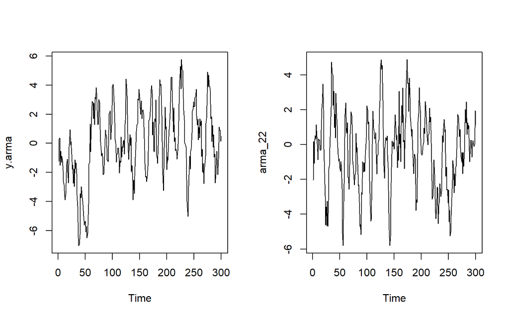

```r
par(mfrow = c(1, 2))
ts.plot(y.arma)
ts.plot(arma_22)
```

```r
par(mfrow = c(1, 1))
```

Berdasarkan plot time series tersebut, terlihat bahwa model ARMA(2,2) cenderung stasioner dalam rataan

### Plot ACF

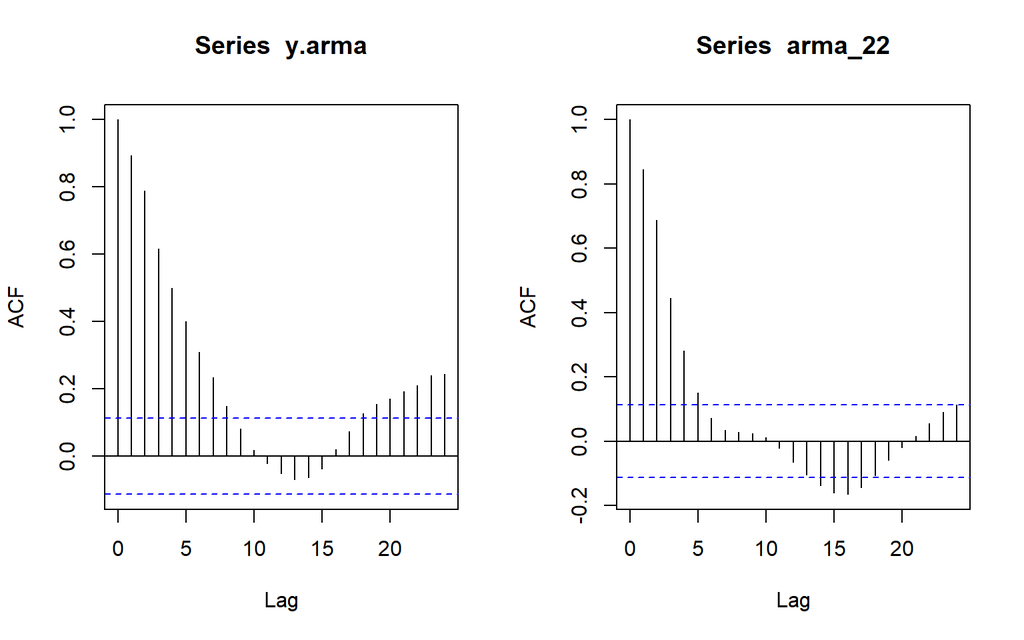

```r
par(mfrow = c(1, 2))
acf(y.arma)
acf(arma_22)
```

```r
par(mfrow = c(1, 1))
```

Berdasarkan plot ACF tersebut, terlihat bahwa model ARMA(2,2) hasil simulasi memiliki plot ACF yang *tails off*, sesuai dengan teori yang ada

### Plot PACF

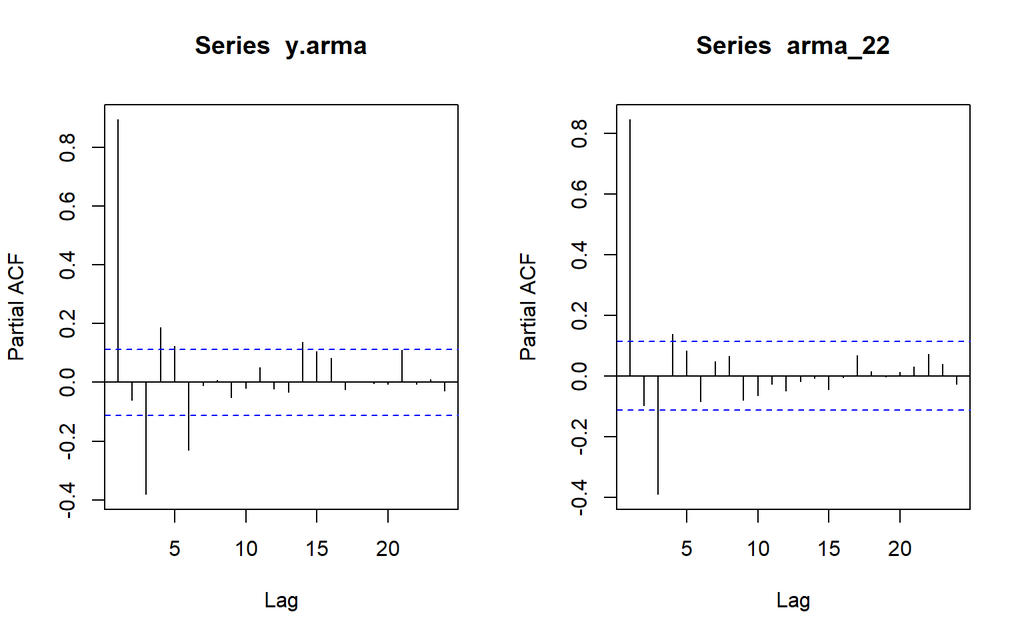

```r
par(mfrow = c(1, 2))
pacf(y.arma)
pacf(arma_22)
```

```r
par(mfrow = c(1, 1))
```

Berdasarkan plot PACF tersebut, terlihat bahwa model ARMA(2,2) hasil simulasi memiliki plot PACF yang *tails off*, sesuai dengan teori

### Plot EACF

```r
TSA::eacf(y.arma)
```

```
## AR/MA
##   0 1 2 3 4 5 6 7 8 9 10 11 12 13
## 0 x x x x x x x x o o o  o  o  o
## 1 o x o o o o x o o o o  o  o  o
## 2 x x o o o o x o o o o  o  o  o
## 3 x x o x o o x o o o o  o  o  o
## 4 x x x x o o x o o o o  o  o  o
## 5 x x x x x x x o o o o  o  o  o
## 6 o o x o x x o o o o o  o  o  o
## 7 o o x o x x o x o o o  o  o  o
```

```r
TSA::eacf(arma_22)
```

```
## AR/MA
##   0 1 2 3 4 5 6 7 8 9 10 11 12 13
## 0 x x x x x o o o o o o  o  o  x
## 1 x x o o o o o o o o o  o  o  o
## 2 x x x x o o o o o o o  o  o  o
## 3 x x o x o o o o o o o  o  o  o
## 4 x x o x x o o o o o o  o  o  o
## 5 x x x x o o o o o o o  o  o  o
## 6 x x x x o x o o o o o  o  o  o
## 7 x x o x x x x o o o o  o  o  o
```

## Scatterplot Antar Lag

### Korelasi antara $Y_t$ dengan $Y_{t-1}$

```r
#Yt
yt_arma <- arma_22[-1]
yt_arma
```

```
##   [1]  0.1804874357 -1.0857429326  0.2019685297  0.5101006237  0.3116647978
##   [6]  1.1440157679  0.4568971792 -0.3804875233 -0.8758133113  0.3166261152
##  [11]  0.2548874061  0.2592079202 -0.3290331722 -0.2948120396  0.8417548499
##  [16]  2.0860897066  2.3426969416  3.4797265438  1.9702862497 -0.2703838028
##  [21] -1.6091794075 -2.9699033669 -4.6121759676 -3.5735246545 -4.6576056483
##  [26] -3.2455887429 -4.7021051669 -3.2231197169 -1.3940059863 -1.1346987187
##  [31] -0.1752041013  1.0623014400  2.1418761113  4.7392121372  4.1182608009
##  [36]  4.0004548088  2.2502034531  3.0645576995  0.9645314951  1.7489003118
##  [41]  0.3724604884  2.9537132225  1.8162605804  1.0974763535  0.1760865572
##  [46] -0.5446303408 -0.9525033432 -0.8123258962 -1.3227469686 -1.5334325506
##  [51] -0.9672480418 -1.3288936550 -2.5250400524 -5.1130294931 -5.8037895789
##  [56] -4.2935914351 -2.2360988083  0.4460497638  1.7472096231  2.4006131137
##  [61]  0.7584947290  0.6515731377  1.2527039433 -1.8771638270 -1.8694819688
##  [66] -2.5578881435 -1.1519209603  0.5748330869  1.1471366303  1.8838444926
##  [71]  1.6757856446  0.6273297035 -0.9358028910 -1.3469021544 -2.0036326762
```

[output cut: 45 more lines]

```r
#Yt-1
yt_1_arma <- arma_22[-300]
yt_1_arma
```

```
##   [1] -2.0296272586  0.1804874357 -1.0857429326  0.2019685297  0.5101006237
##   [6]  0.3116647978  1.1440157679  0.4568971792 -0.3804875233 -0.8758133113
##  [11]  0.3166261152  0.2548874061  0.2592079202 -0.3290331722 -0.2948120396
##  [16]  0.8417548499  2.0860897066  2.3426969416  3.4797265438  1.9702862497
##  [21] -0.2703838028 -1.6091794075 -2.9699033669 -4.6121759676 -3.5735246545
##  [26] -4.6576056483 -3.2455887429 -4.7021051669 -3.2231197169 -1.3940059863
##  [31] -1.1346987187 -0.1752041013  1.0623014400  2.1418761113  4.7392121372
##  [36]  4.1182608009  4.0004548088  2.2502034531  3.0645576995  0.9645314951
##  [41]  1.7489003118  0.3724604884  2.9537132225  1.8162605804  1.0974763535
##  [46]  0.1760865572 -0.5446303408 -0.9525033432 -0.8123258962 -1.3227469686
##  [51] -1.5334325506 -0.9672480418 -1.3288936550 -2.5250400524 -5.1130294931
##  [56] -5.8037895789 -4.2935914351 -2.2360988083  0.4460497638  1.7472096231
##  [61]  2.4006131137  0.7584947290  0.6515731377  1.2527039433 -1.8771638270
##  [66] -1.8694819688 -2.5578881435 -1.1519209603  0.5748330869  1.1471366303
##  [71]  1.8838444926  1.6757856446  0.6273297035 -0.9358028910 -1.3469021544
```

[output cut: 45 more lines]

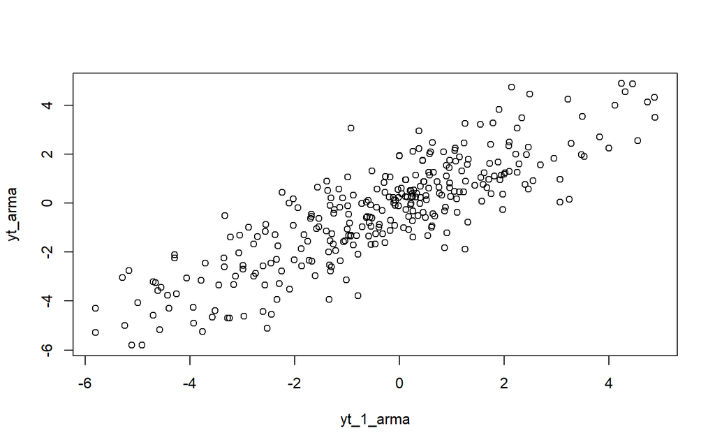

```r
plot(y=yt_arma,x=yt_1_arma)
```

Berdasarkan scatterplot tersebut, terlihat bahwa terdapat hubungan positif antara $Y_t$ dengan $Y_{t-1}$. Hal ini sesuai dengan teori yang ada

```r
cor(yt_arma,yt_1_arma)
```

```
## [1] 0.8469229
```

Korelasi antara $Y_t$ dengan $Y_{t-1}$ dari hasil simulasi mendekati perhitungan teoritis.

Untuk korelasi pada lag 1 dan lag 2 diperoleh dari persamaan kovarians:

$$\gamma_0=0.5\gamma_1+0.2\gamma_2+2.11$$

$$\gamma_1=0.5\gamma_0+0.2\gamma_1+0.94$$

Hasil penyelesaian:

$$\gamma_0=5.0171,\quad
\gamma_1=4.3107$$

Korelasi antara $Y_t$ dan $Y_{t-1}$:

$$\rho_1=\frac{\gamma_1}{\gamma_0} =\frac{4.3107}{5.0171}=0.8592$$

### Korelasi antara $Y_t$ dengan $Y_{t-2}$

```r
#Yt
yt_arma2 <- arma_22[-c(1,2)]
yt_arma2
```

```
##   [1] -1.0857429326  0.2019685297  0.5101006237  0.3116647978  1.1440157679
##   [6]  0.4568971792 -0.3804875233 -0.8758133113  0.3166261152  0.2548874061
##  [11]  0.2592079202 -0.3290331722 -0.2948120396  0.8417548499  2.0860897066
##  [16]  2.3426969416  3.4797265438  1.9702862497 -0.2703838028 -1.6091794075
##  [21] -2.9699033669 -4.6121759676 -3.5735246545 -4.6576056483 -3.2455887429
##  [26] -4.7021051669 -3.2231197169 -1.3940059863 -1.1346987187 -0.1752041013
##  [31]  1.0623014400  2.1418761113  4.7392121372  4.1182608009  4.0004548088
##  [36]  2.2502034531  3.0645576995  0.9645314951  1.7489003118  0.3724604884
##  [41]  2.9537132225  1.8162605804  1.0974763535  0.1760865572 -0.5446303408
##  [46] -0.9525033432 -0.8123258962 -1.3227469686 -1.5334325506 -0.9672480418
##  [51] -1.3288936550 -2.5250400524 -5.1130294931 -5.8037895789 -4.2935914351
##  [56] -2.2360988083  0.4460497638  1.7472096231  2.4006131137  0.7584947290
##  [61]  0.6515731377  1.2527039433 -1.8771638270 -1.8694819688 -2.5578881435
##  [66] -1.1519209603  0.5748330869  1.1471366303  1.8838444926  1.6757856446
##  [71]  0.6273297035 -0.9358028910 -1.3469021544 -2.0036326762 -2.3174267020
```

[output cut: 45 more lines]

```r
#Yt-2
yt_2_arma <- arma_22[-c(299, 300)]
yt_2_arma
```

```
##   [1] -2.0296272586  0.1804874357 -1.0857429326  0.2019685297  0.5101006237
##   [6]  0.3116647978  1.1440157679  0.4568971792 -0.3804875233 -0.8758133113
##  [11]  0.3166261152  0.2548874061  0.2592079202 -0.3290331722 -0.2948120396
##  [16]  0.8417548499  2.0860897066  2.3426969416  3.4797265438  1.9702862497
##  [21] -0.2703838028 -1.6091794075 -2.9699033669 -4.6121759676 -3.5735246545
##  [26] -4.6576056483 -3.2455887429 -4.7021051669 -3.2231197169 -1.3940059863
##  [31] -1.1346987187 -0.1752041013  1.0623014400  2.1418761113  4.7392121372
##  [36]  4.1182608009  4.0004548088  2.2502034531  3.0645576995  0.9645314951
##  [41]  1.7489003118  0.3724604884  2.9537132225  1.8162605804  1.0974763535
##  [46]  0.1760865572 -0.5446303408 -0.9525033432 -0.8123258962 -1.3227469686
##  [51] -1.5334325506 -0.9672480418 -1.3288936550 -2.5250400524 -5.1130294931
##  [56] -5.8037895789 -4.2935914351 -2.2360988083  0.4460497638  1.7472096231
##  [61]  2.4006131137  0.7584947290  0.6515731377  1.2527039433 -1.8771638270
##  [66] -1.8694819688 -2.5578881435 -1.1519209603  0.5748330869  1.1471366303
##  [71]  1.8838444926  1.6757856446  0.6273297035 -0.9358028910 -1.3469021544
```

[output cut: 45 more lines]

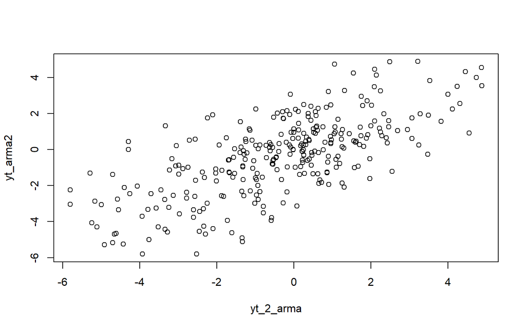

```r
plot(y=yt_arma2,x=yt_2_arma)
```

Berdasarkan scatterplot tersebut, terlihat bahwa terdapat hubungan positif antara $Y_t$ dengan $Y_{t-2}$. Hal ini sesuai dengan teori yang ada

```r
cor(yt_arma2,yt_2_arma)
```

```
## [1] 0.689796
```

Korelasi antara $Y_t$ dengan $Y_{t-2}$ dari hasil simulasi mendekati perhitungan teoritis.

$$\rho_2=\frac{\gamma_2}{\gamma_0}$$
$$\gamma_2=0.5\gamma_1+0.2\gamma_0+0.6$$
$$\rho_2=\frac{3.7588}{5.0171}=0.7492$$

### Korelasi antara $Y_t$ dengan $Y_{t-3}$

```r
#Yt
yt_arma3 <- arma_22[-c(1,2,3)]
yt_arma3
```

```
##   [1]  0.2019685297  0.5101006237  0.3116647978  1.1440157679  0.4568971792
##   [6] -0.3804875233 -0.8758133113  0.3166261152  0.2548874061  0.2592079202
##  [11] -0.3290331722 -0.2948120396  0.8417548499  2.0860897066  2.3426969416
##  [16]  3.4797265438  1.9702862497 -0.2703838028 -1.6091794075 -2.9699033669
##  [21] -4.6121759676 -3.5735246545 -4.6576056483 -3.2455887429 -4.7021051669
##  [26] -3.2231197169 -1.3940059863 -1.1346987187 -0.1752041013  1.0623014400
##  [31]  2.1418761113  4.7392121372  4.1182608009  4.0004548088  2.2502034531
##  [36]  3.0645576995  0.9645314951  1.7489003118  0.3724604884  2.9537132225
##  [41]  1.8162605804  1.0974763535  0.1760865572 -0.5446303408 -0.9525033432
##  [46] -0.8123258962 -1.3227469686 -1.5334325506 -0.9672480418 -1.3288936550
##  [51] -2.5250400524 -5.1130294931 -5.8037895789 -4.2935914351 -2.2360988083
##  [56]  0.4460497638  1.7472096231  2.4006131137  0.7584947290  0.6515731377
##  [61]  1.2527039433 -1.8771638270 -1.8694819688 -2.5578881435 -1.1519209603
##  [66]  0.5748330869  1.1471366303  1.8838444926  1.6757856446  0.6273297035
##  [71] -0.9358028910 -1.3469021544 -2.0036326762 -2.3174267020 -1.7545802003
```

[output cut: 45 more lines]

```r
#Yt-3
yt_3_arma <- arma_22[-c(298, 299,300)]
yt_3_arma
```

```
##   [1] -2.0296272586  0.1804874357 -1.0857429326  0.2019685297  0.5101006237
##   [6]  0.3116647978  1.1440157679  0.4568971792 -0.3804875233 -0.8758133113
##  [11]  0.3166261152  0.2548874061  0.2592079202 -0.3290331722 -0.2948120396
##  [16]  0.8417548499  2.0860897066  2.3426969416  3.4797265438  1.9702862497
##  [21] -0.2703838028 -1.6091794075 -2.9699033669 -4.6121759676 -3.5735246545
##  [26] -4.6576056483 -3.2455887429 -4.7021051669 -3.2231197169 -1.3940059863
##  [31] -1.1346987187 -0.1752041013  1.0623014400  2.1418761113  4.7392121372
##  [36]  4.1182608009  4.0004548088  2.2502034531  3.0645576995  0.9645314951
##  [41]  1.7489003118  0.3724604884  2.9537132225  1.8162605804  1.0974763535
##  [46]  0.1760865572 -0.5446303408 -0.9525033432 -0.8123258962 -1.3227469686
##  [51] -1.5334325506 -0.9672480418 -1.3288936550 -2.5250400524 -5.1130294931
##  [56] -5.8037895789 -4.2935914351 -2.2360988083  0.4460497638  1.7472096231
##  [61]  2.4006131137  0.7584947290  0.6515731377  1.2527039433 -1.8771638270
##  [66] -1.8694819688 -2.5578881435 -1.1519209603  0.5748330869  1.1471366303
##  [71]  1.8838444926  1.6757856446  0.6273297035 -0.9358028910 -1.3469021544
```

[output cut: 45 more lines]

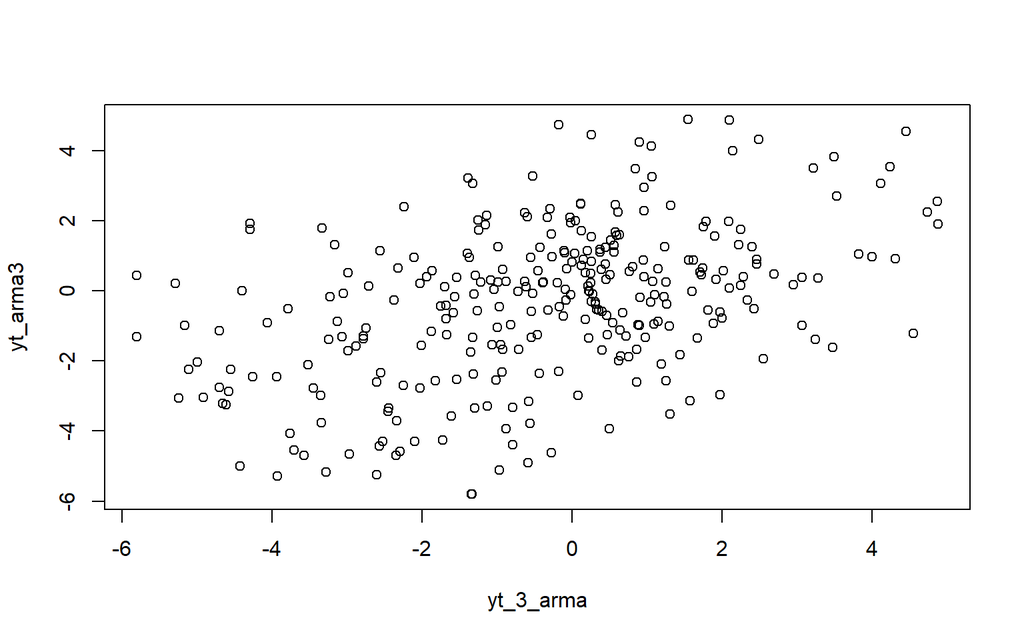

```r
plot(y=yt_arma3,x=yt_3_arma)
```

Berdasarkan scatterplot tersebut, terlihat bahwa terdapat hubungan positif antara $Y_t$ dengan $Y_{t-3}$. Hal ini sesuai dengan teori yang ada

```r
cor(yt_arma3,yt_3_arma)
```

```
## [1] 0.4468638
```

Korelasi antara $Y_t$ dengan $Y_{t-3}$ dari hasil simulasi mendekati perhitungan teoritis.

$$\rho_3=\phi_1\rho_2+\phi_2\rho_1$$

$$\rho_3=(0.5)(0.7492)+(0.2)(0.8592)$$

$$\rho_3=0.3746+0.1718=0.5464$$